# Session 4: Data Viz Challenge

Data Wrangling I

Your Name

14 Juli 2021

# Data Viz Challenge

```r
whogov <- import("data/WhoGov_crosssectional_V1.2.csv")
```

Since data visualization is about creativity and just trying things out, we will take a different approach in this problem set.

Together with your group you will work on the [WhoGov](https://politicscentre.nuffield.ox.ac.uk/whogov-dataset/) data set. It provides information on governing elites.

1. **Everyone on her/his own (10min):** Skim the [codebook](https://politicscentre.nuffield.ox.ac.uk/media/4117/whogov_codebook.pdf) part **B**. We will **only use the cross-sectional data**.
2. **Together in your group (10min):** Discuss the data and agree on something interesting you want to visualize.
3. **Everyone on her/his own (30mins):** Implement the visualization you agreed upon in R. Tipp: You can use all the links and pointers from the slides or google when you are stuck!
4. **Together in your group (10mins):** Share your versions with your group. Pick the best and fine-tune it together. If you like multiple versions, combine them into one plot/data story.

Back in the plenum, we will pick a winner!

Criteria:

- Is it a truthful display of the data?
- Is it functional?
- Is it pretty?
- Is it insightful?

# An exemplary “Solution”

Visualizing the share of female ministers over time by system type.

```r
# Define a ggplot theme

extrafont::loadfonts() # You must download and install IBM Plex from google fonts and register it with extrafont. Consult the package doc.

plex <- theme_ipsum() +
  theme(
    text = element_text(colour = "#415564", family = "IBM Plex Sans"),
    plot.title = element_text(colour = "#415564", family = "IBM Plex Sans"),
    plot.subtitle = element_text(colour = "#415564", family = "IBM Plex Sans"),
    plot.background = element_rect(fill = "#ffffff", color = "#ffffff"),
    panel.border = element_blank(),
    strip.text = element_text(colour = "#415564"),
    axis.text = element_text(colour = "#415564"),
    axis.title = element_text(colour = "#415564")
  )

theme_set(plex)


# Create a crosstab of the system_category and arrange by n

whogov %>%
  count(system_category) %>%
  arrange(n)
```

```
##              system_category    n
## 1               Crown Colony    2
## 2         Part of Yugoslavia    9
## 3  French Overseas Territory   10
## 4               Presidential   35
## 5         Royal dictatorship  576
## 6           Mixed democratic  941
## 7     Presidential democracy 1141
## 8    Parliamentary democracy 1471
## 9      Military dictatorship 1567
## 10     Civilian dictatorship 2307
```

```r
# Add a variable "regime_type" that takes on the value "democratic" if system_category
# contains the string "democ", "Dictatorship" if "dict", and "Other" otherwise.

whogov <- whogov %>%
  mutate(regime_type = case_when(
    stringr::str_detect(system_category, "dict") ~ "Dictatorship",
    stringr::str_detect(system_category, "democ") ~ "Democracy",
    TRUE ~ "Other"
  ))

# Create a crosstab of the system_category and regime_type

whogov %>%
  count(system_category, regime_type) %>%
  arrange(n)
```

```
##              system_category  regime_type    n
## 1               Crown Colony        Other    2
## 2         Part of Yugoslavia        Other    9
## 3  French Overseas Territory        Other   10
## 4               Presidential        Other   35
## 5         Royal dictatorship Dictatorship  576
## 6           Mixed democratic    Democracy  941
## 7     Presidential democracy    Democracy 1141
## 8    Parliamentary democracy    Democracy 1471
## 9      Military dictatorship Dictatorship 1567
## 10     Civilian dictatorship Dictatorship 2307
```

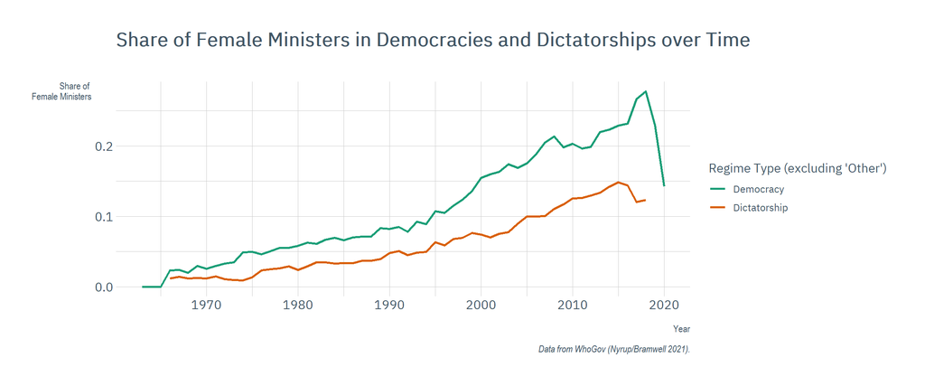

```r
plot_table <- whogov %>%
  mutate(share_fem_min = n_female_minister / n_minister) %>%
  group_by(year, regime_type) %>%
  summarise(avg_share_fem_minister = mean(share_fem_min, na.rm = TRUE)) %>%
  filter(regime_type != "Other")

ggplot(plot_table, aes(x = year, y = avg_share_fem_minister, color = regime_type)) +
  geom_line() +
  geom_line(size = 1) +
  scale_colour_brewer(palette = "Dark2") +
  scale_x_continuous(breaks = seq(1960, 2020, 10)) +
  labs(
    x = "\nYear",
    y = "Share of \nFemale Ministers",
    color = "Regime Type (excluding 'Other')",
    title = "Share of Female Ministers in Democracies and Dictatorships over Time\n",
    caption = "Data from WhoGov (Nyrup/Bramwell 2021)."
  ) +
  theme(axis.title.y = element_text(angle = 0)) # rotate y axis label.
```